# WNBA Player Stats Season 2016-2017

```python
import pandas as pd
wnba=pd.read_csv('WNBA Stats.csv')
```

```python
wnba.head()
```

|  | Name | Team | Pos | Height | Weight | BMI | Birth_Place | Birthdate | Age | College | ... | OREB | DREB | REB | AST | STL | BLK | TO | PTS | DD2 | TD3 |
| --- | --- | --- | --- | --- | --- | --- | --- | --- | --- | --- | --- | --- | --- | --- | --- | --- | --- | --- | --- | --- | --- |
| 0 | Aerial Powers | DAL | F | 183 | 71.0 | 21.200991 | US | January 17, 1994 | 23 | Michigan State | ... | 6 | 22 | 28 | 12 | 3 | 6 | 12 | 93 | 0 | 0 |
| 1 | Alana Beard | LA | G/F | 185 | 73.0 | 21.329438 | US | May 14, 1982 | 35 | Duke | ... | 19 | 82 | 101 | 72 | 63 | 13 | 40 | 217 | 0 | 0 |
| 2 | Alex Bentley | CON | G | 170 | 69.0 | 23.875433 | US | October 27, 1990 | 26 | Penn State | ... | 4 | 36 | 40 | 78 | 22 | 3 | 24 | 218 | 0 | 0 |
| 3 | Alex Montgomery | SAN | G/F | 185 | 84.0 | 24.543462 | US | December 11, 1988 | 28 | Georgia Tech | ... | 35 | 134 | 169 | 65 | 20 | 10 | 38 | 188 | 2 | 0 |
| 4 | Alexis Jones | MIN | G | 175 | 78.0 | 25.469388 | US | August 5, 1994 | 23 | Baylor | ... | 3 | 9 | 12 | 12 | 7 | 0 | 14 | 50 | 0 | 0 |

5 rows × 32 columns

```python
wnba.tail()
```

|  | Name | Team | Pos | Height | Weight | BMI | Birth_Place | Birthdate | Age | College | ... | OREB | DREB | REB | AST | STL | BLK | TO | PTS | DD2 | TD3 |
| --- | --- | --- | --- | --- | --- | --- | --- | --- | --- | --- | --- | --- | --- | --- | --- | --- | --- | --- | --- | --- | --- |
| 138 | Tiffany Hayes | ATL | G | 178 | 70.0 | 22.093170 | US | September 20, 1989 | 27 | Connecticut | ... | 28 | 89 | 117 | 69 | 37 | 8 | 50 | 467 | 0 | 0 |
| 139 | Tiffany Jackson | LA | F | 191 | 84.0 | 23.025685 | US | April 26, 1985 | 32 | Texas | ... | 5 | 18 | 23 | 3 | 1 | 3 | 8 | 28 | 0 | 0 |
| 140 | Tiffany Mitchell | IND | G | 175 | 69.0 | 22.530612 | US | September 23, 1984 | 32 | South Carolina | ... | 16 | 70 | 86 | 39 | 31 | 5 | 40 | 277 | 0 | 0 |
| 141 | Tina Charles | NY | F/C | 193 | 84.0 | 22.550941 | US | May 12, 1988 | 29 | Connecticut | ... | 56 | 212 | 268 | 75 | 21 | 22 | 71 | 582 | 11 | 0 |
| 142 | Yvonne Turner | PHO | G | 175 | 59.0 | 19.265306 | US | October 13, 1987 | 29 | Nebraska | ... | 11 | 13 | 24 | 30 | 18 | 1 | 32 | 151 | 0 | 0 |

5 rows × 32 columns

Getting the number of rows and columns

```python
wnba.shape
```

```
(143, 32)
```

We use the `Games Played` column to find the maximum number of games played by a player in the season 2016-2017. This data set contains all the players that had at least one game, so it's a population relative to our question.

```python
parameter= wnba['Games Played'].max()
```

```python
parameter
```

```
32
```

Using the Series.sample() method, I will sample randomly 30 players from the population, and assign the result to a variable named sample.

When calling Series.sample(), we use the the argument random_state = 1. This makes the results reproducible and helps us with the answer checking

We use the random_state parameter,Series.sample(30, random_state = 1), we make the generation of random numbers predictable.

```python
sample= wnba['Games Played'].sample(30,random_state=1)
statistic= sample.max()
```

```python
sampling_error= parameter - statistic
```

```python
sampling_error
```

```
2
```

Using simple random sampling, I will take 100 samples from our WNBA data set, and for each sample measure the average points scored by a player during the 2016-2017 season. For each of the 100 iterations of a for loop:

- Sample 10 values from the PTS column.
- Compute the mean of this sample made of 10 values from the PTS column, and append the result to a list.
- To make your results reproducible, vary the random_state parameter of the sample() method with values between 0 and 99. For the first iteration of the for loop, random_state should equal 0, for the second iteration should equal 1, for the third should equal 2, and so on.

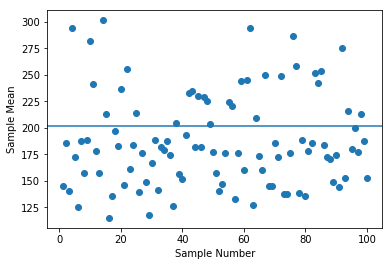

```python
import matplotlib.pyplot as plt

sample_means = []
population_mean = wnba['PTS'].mean()

for i in range(100):
    sample = wnba['PTS'].sample(10, random_state=i)
    sample_means.append(sample.mean())

    plt.ylabel('Sample Mean')
    plt.xlabel('Sample Number')
plt.scatter(range(1,101), sample_means)
plt.axhline(population_mean)
```

```python
population_mean
```

```
201.7902097902098
```

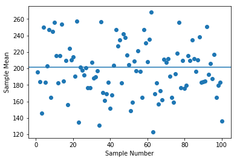

```python
import matplotlib.pyplot as plt

sample_means = []
population_mean = wnba['PTS'].mean()

for i in range(100):
    sample = wnba['PTS'].sample(20, random_state=i)
    sample_means.append(sample.mean())

    plt.ylabel('Sample Mean')
    plt.xlabel('Sample Number')
plt.scatter(range(1,101), sample_means)
plt.axhline(population_mean)
```

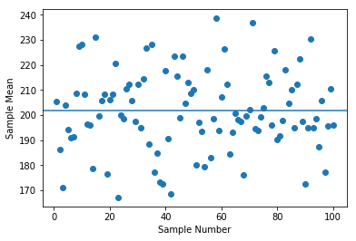

```python
import matplotlib.pyplot as plt

sample_means = []
population_mean = wnba['PTS'].mean()

for i in range(100):
    sample = wnba['PTS'].sample(60, random_state=i)
    sample_means.append(sample.mean())

    plt.ylabel('Sample Mean')
    plt.xlabel('Sample Number')
plt.scatter(range(1,101), sample_means)
plt.axhline(population_mean)
```

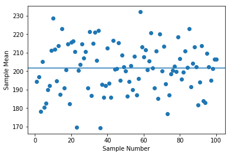

```python
import matplotlib.pyplot as plt

sample_means = []
population_mean = wnba['PTS'].mean()

for i in range(100):
    sample = wnba['PTS'].sample(80, random_state=i)
    sample_means.append(sample.mean())

    plt.ylabel('Sample Mean')
    plt.xlabel('Sample Number')
plt.scatter(range(1,101), sample_means)
plt.axhline(population_mean)
```

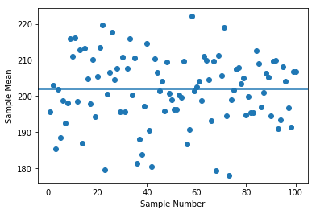

```python
import matplotlib.pyplot as plt

sample_means = []
population_mean = wnba['PTS'].mean()

for i in range(100):
    sample = wnba['PTS'].sample(100, random_state=i)
    sample_means.append(sample.mean())

    plt.ylabel('Sample Mean')
    plt.xlabel('Sample Number')
plt.scatter(range(1,101), sample_means)
plt.axhline(population_mean)
```

From the plots above, we can see how sample means tend to vary less and less around the population mean as we increase the sample size.

From the observation we can make two conclusions:

- Simple random sampling is not a reliable sampling method when the sample size is small, because sample means vary a lot around the population mean, there's a good chance we'll get an unrepresentative sample.
- When we do simple random sampling, we should try to get a sample that is as large as possible. A large sample decreases the variability of the sampling process, which in turn decreases the chances that we'll get an unrepresentative sample.

The metrics of a player (number of points, number of assists, etc.) depend on their position, and we might want to analyze the patterns for each individual position.

F - Forward

G - Guard

C - Center

G/F - Guard/Forward

F/C - Forward/Center

```python
print(wnba['Pos'].unique())
```

```
['F' 'G/F' 'G' 'C' 'F/C']
```

We will create a new column which describes the number of points a player scored per game during the season. The number of total points a player scored the entire season is stored in the PTS column, and the number of games played in the Games Played column.

We stratify the wnba data set by player position. The Pos column describes a player's position on the field. Assign each stratum to a different variable.

```python
wnba['Pts_per_game'] = wnba['PTS'] / wnba['Games Played']

# Stratifying the data in five strata
stratum_G = wnba[wnba.Pos == 'G']
stratum_F = wnba[wnba.Pos == 'F']
stratum_C = wnba[wnba.Pos == 'C']
stratum_GF = wnba[wnba.Pos == 'G/F']
stratum_FC = wnba[wnba.Pos == 'F/C']

points_per_position = {}
for stratum, position in [(stratum_G, 'G'), (stratum_F, 'F'), (stratum_C, 'C'),
                (stratum_GF, 'G/F'), (stratum_FC, 'F/C')]:

    sample = stratum['Pts_per_game'].sample(10, random_state = 0) # simple random sapling on each stratum
    points_per_position[position] = sample.mean()

position_most_points = max(points_per_position, key = points_per_position.get)
```

```python
print(wnba['Games Played'].min())
```

```
2
```

```python
print(wnba['Games Played'].max())
```

```
32
```

```python
print(wnba['Games Played'].value_counts(bins = 3, normalize = True) * 100)
```

```
(22.0, 32.0]     72.727273
(12.0, 22.0]     18.181818
(1.969, 12.0]     9.090909
Name: Games Played, dtype: float64
```

We Perform stratified sampling on the data set 100 times, and sample strata proportionally.

- Stratify the data set by the number of games played in the following way: the first strata should be composed of players that played 12 games or less; the second of players that played more than 12 games, but up to 22 (included); and the third of players that played more than 22 games (22 not included).
- We Perform stratified sampling 100 times. For each of the 100 iterations of a for loop:
  - Sample each stratum proportionally. Sample at random: one sample observation from the first stratum, two sample observations from the second, and seven sample observations from the third stratum.
    - `random_state` should vary from 0 to 99: 0 for the first iteration, 99 for the last iteration.
- Once you're done with the sampling for the current iteration of the loop, concatenate all the sample observations into one final sample. You can use pd.concat().
- Compute the mean of the final sample, and append it to a list defined outside the loop. The mean should be for the PTS column.
- Display the entire sampling process.
  - Using plt.scatter(), display the sampling means on a scatter plot. Place the means on the y-axis, and the sample numbers on the x-axis (the numbers should range from 1 to 100 - both endpoints included).
    - Using plt.axhline(), display the population mean for the total points in the form of a horizontal line.

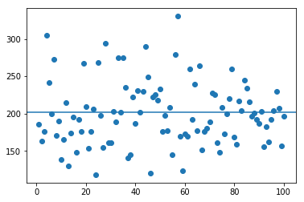

```python
under_12 = wnba[wnba['Games Played'] <= 12]
btw_13_22 = wnba[(wnba['Games Played'] > 12) & (wnba['Games Played'] <= 22)]
over_23 = wnba[wnba['Games Played'] > 22]

proportional_sampling_means = []

for i in range(100):
    sample_under_12 = under_12['PTS'].sample(1, random_state = i)
    sample_btw_13_22 = btw_13_22['PTS'].sample(2, random_state = i)
    sample_over_23 = over_23['PTS'].sample(7, random_state = i)

    final_sample = pd.concat([sample_under_12, sample_btw_13_22, sample_over_23])
    proportional_sampling_means.append(final_sample.mean())

plt.scatter(range(1,101), proportional_sampling_means)
plt.axhline(wnba['PTS'].mean())
```

The variability of the sampling was quite large, and many sample means were unrepresentative, being far from the population mean. In fact, this sampling method doesn't seem to perform better than simple random sampling.

The poor performance is caused by a bad choice of strata. We stratified the data by the number of games played, but this isn't a good approach. A player is considered as having played one game even if she only played for one or two minutes. But others play 30 or 40 minutes, and they're still considered as having played one game.

It makes more sense to stratify the data by number of minutes played, rather than by number of games played. The minutes played are a much better indicator of how much a player scored in a season than the number of games played.

In our case, we'd first list all the possible data sources. Assuming that all the teams in our data set have a website where we can take data from, we end up with this list of clusters (each team's website is considered a cluster) :

```python
print(wnba['Team'].unique())
```

```
['DAL' 'LA' 'CON' 'SAN' 'MIN' 'SEA' 'PHO' 'CHI' 'WAS' 'NY' 'ATL' 'IND']
```

We need to find a way to pick randomly a few clusters from our listing. There are many ways to do that, but the important thing to keep in mind is that we should avoid picking a cluster twice.

Sample four clusters randomly:

```python
print(pd.Series(wnba['Team'].unique()).sample(4, random_state=0))
```

```
6     PHO
11    IND
4     MIN
10    ATL
dtype: object
```

```python
clusters = pd.Series(wnba['Team'].unique()).sample(4, random_state = 0)

sample = pd.DataFrame()

for cluster in clusters:
    data_collected = wnba[wnba['Team'] == cluster]
    sample = sample.append(data_collected)

sampling_error_height = wnba['Height'].mean() - sample['Height'].mean()
sampling_error_age = wnba['Age'].mean() - sample['Age'].mean()
sampling_error_BMI = wnba['BMI'].mean() - sample['BMI'].mean()
sampling_error_points = wnba['PTS'].mean() - sample['PTS'].mean()
```

```python
sampling_error_height
```

```
-0.06400121617511445
```

```python
sampling_error_age
```

```
-1.401337792642142
```

```python
sampling_error_BMI
```

```
0.23095444165950596
```

```python
sampling_error_points
```

```
-27.79674673152934
```